# Regression models for paper - Breathing and speech adaptation

Tom Offrede

2022-09-21

# Breathing data while listening/watching (participants)

## Breathing rate

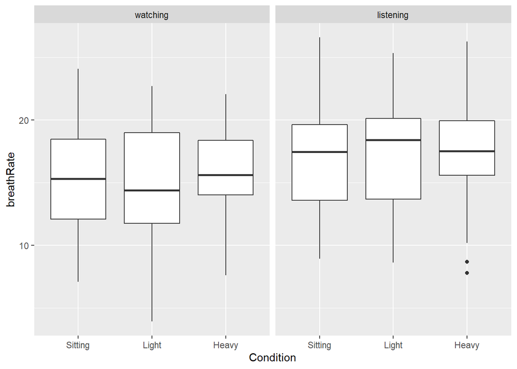

```r
ggplot(dat, aes(Condition, breathRate))+
  geom_boxplot()+
  facet_wrap(~act)+
  scale_x_discrete(limits = orderCond)
```

- Breathing rate is faster while listening to confederate than only watching in silence. Listening is more cognitively effortful, so this result makes sense.

The graphs seem to visually indicate that there was a trend for an interaction with `condition`, but the model `breathing rate ~ act` (without `condition`) is the best model.

```r
summary(m2a <- lmer(breathRate ~ act + (1+act |Speaker), dat))
```

```
## Linear mixed model fit by REML ['lmerMod']
## Formula: breathRate ~ act + (1 + act | Speaker)
##    Data: dat
##
## REML criterion at convergence: 628.4
##
## Scaled residuals:
##     Min      1Q  Median      3Q     Max
## -3.6504 -0.4881  0.0253  0.5134  3.5916
##
## Random effects:
##  Groups   Name         Variance Std.Dev. Corr
##  Speaker  (Intercept)  14.593   3.820
##           actlistening  1.268   1.126    0.58
##  Residual               5.147   2.269
## Number of obs: 126, groups:  Speaker, 21
##
## Fixed effects:
##              Estimate Std. Error t value
## (Intercept)   15.1784     0.8813  17.224
## actlistening   1.9997     0.4730   4.227
##
## Correlation of Fixed Effects:
##             (Intr)
## actlistenng 0.090
```

```r
summary(m2.1 <- lmer(breathRate ~ Condition + (1 |Speaker), dat %>% filter(act=="listening"))) # random slope causes the model not to converge
```

```
## Linear mixed model fit by REML ['lmerMod']
## Formula: breathRate ~ Condition + (1 | Speaker)
##    Data: dat %>% filter(act == "listening")
##
## REML criterion at convergence: 294.1
##
## Scaled residuals:
##      Min       1Q   Median       3Q      Max
## -1.86271 -0.47116  0.09018  0.48358  2.54252
##
## Random effects:
##  Groups   Name        Variance Std.Dev.
##  Speaker  (Intercept) 21.87    4.676
##  Residual              2.14    1.463
## Number of obs: 63, groups:  Speaker, 21
##
## Fixed effects:
##                Estimate Std. Error t value
## (Intercept)    17.04263    1.06915  15.940
## ConditionLight  0.05143    0.45141   0.114
## ConditionHeavy  0.35511    0.45141   0.787
##
## Correlation of Fixed Effects:
##             (Intr) CndtnL
## ConditnLght -0.211
## ConditinHvy -0.211  0.500
```

```r
summary(m2.2 <- lmer(breathRate ~ Condition + (1 |Speaker), dat %>% filter(act=="watching"))) # random slope causes the model not to converge
```

```
## Linear mixed model fit by REML ['lmerMod']
## Formula: breathRate ~ Condition + (1 | Speaker)
##    Data: dat %>% filter(act == "watching")
##
## REML criterion at convergence: 342.5
##
## Scaled residuals:
##      Min       1Q   Median       3Q      Max
## -2.33616 -0.37408 -0.02463  0.49800  2.56315
##
## Random effects:
##  Groups   Name        Variance Std.Dev.
##  Speaker  (Intercept) 13.497   3.674
##  Residual              8.435   2.904
## Number of obs: 63, groups:  Speaker, 21
##
## Fixed effects:
##                Estimate Std. Error t value
## (Intercept)    15.46815    1.02196  15.136
## ConditionLight -0.78478    0.89631  -0.876
## ConditionHeavy -0.08446    0.89631  -0.094
##
## Correlation of Fixed Effects:
##             (Intr) CndtnL
## ConditnLght -0.439
## ConditinHvy -0.439  0.500
```

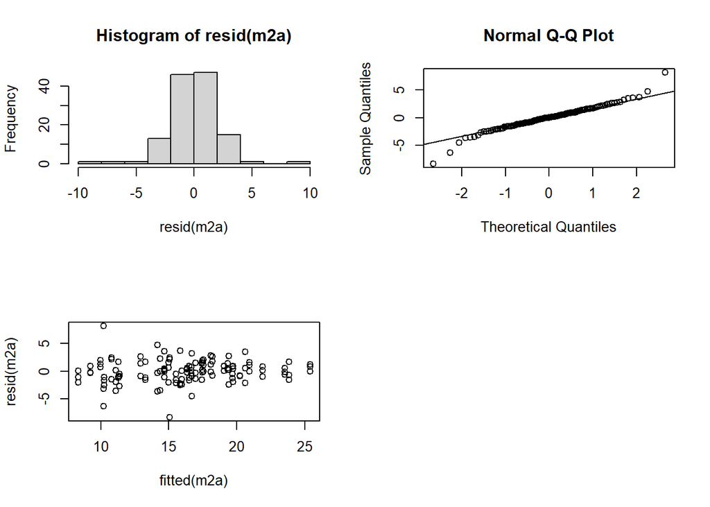

```r
par(mfrow=c(2, 2))
hist(resid(m2a))
qqnorm(resid(m2a));qqline(resid(m2a))
plot(fitted(m2a), resid(m2a))
```

## Breath cycle duration

We also have models about breath cycle durations, but those indicate the same things as breathing rate, since they’re closely (negatively) related. It may still be worth it to look at effects on cycle duration: there are more data points with cycle duration than with breathing rate, so some more effects can emerge with cycles and not with rate.

One interesting thing was that breath cycles tended to be shorter the further into the recording they were. (Helene also observed this in her data.) I don’t think this is relevant for our overall story, but let’s keep it in mind.

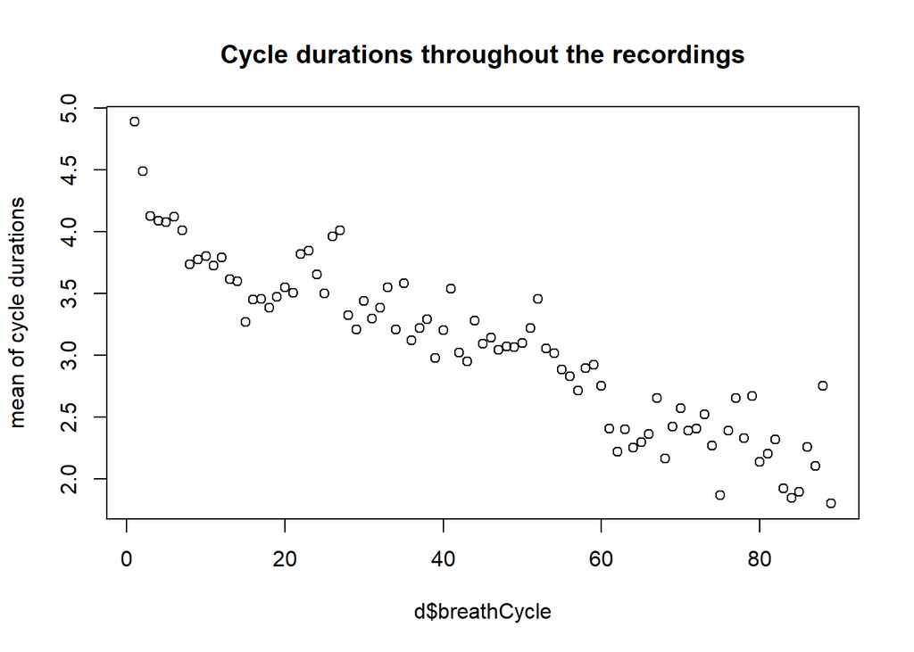

```r
plot(d$breathCycle, d$cM, ylab="mean of cycle durations", main="Cycle durations throughout the recordings")
```

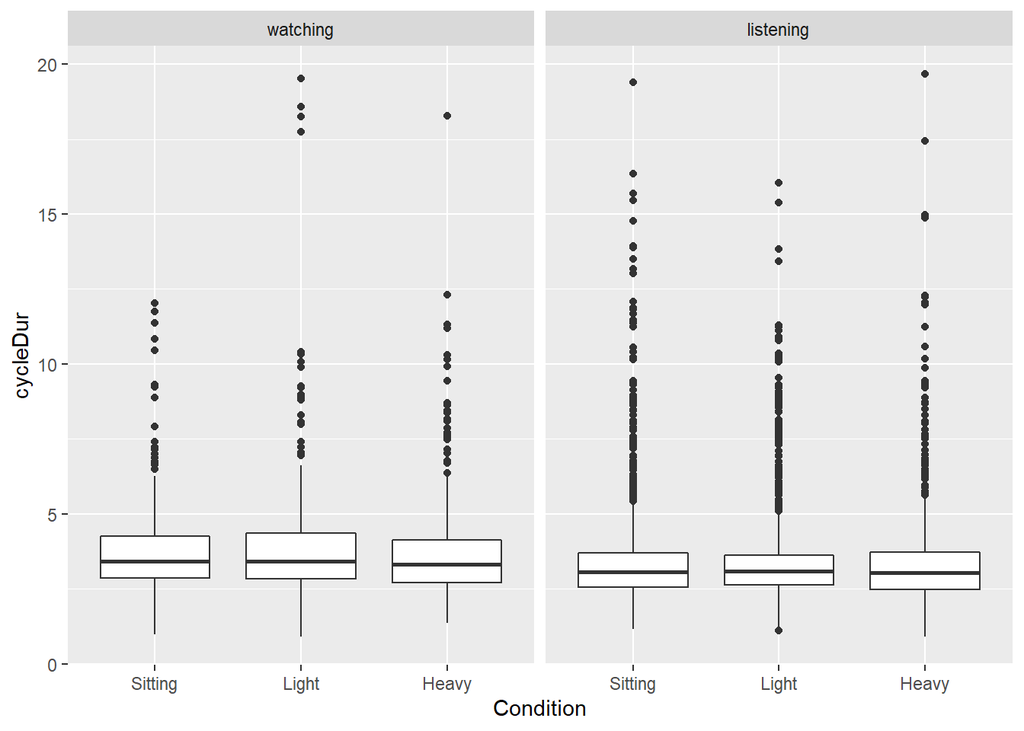

```r
ggplot(dat, aes(Condition, cycleDur))+
  geom_boxplot()+
  facet_wrap(~act)+
  scale_x_discrete(limits = orderCond)
```

Cycle durations are shorter during listening than watching (like for breathing rate). There are no condition effects.

```r
summary(c1 <- lmer(cycleDur ~ act + (1+ act |Speaker), dat))
```

```
## Linear mixed model fit by REML ['lmerMod']
## Formula: cycleDur ~ act + (1 + act | Speaker)
##    Data: dat
##
## REML criterion at convergence: 14350
##
## Scaled residuals:
##     Min      1Q  Median      3Q     Max
## -3.3684 -0.3506 -0.0981  0.1734 10.5113
##
## Random effects:
##  Groups   Name         Variance Std.Dev. Corr
##  Speaker  (Intercept)  1.625    1.2747
##           actlistening 0.510    0.7141   -0.25
##  Residual              2.250    1.5001
## Number of obs: 3893, groups:  Speaker, 21
##
## Fixed effects:
##              Estimate Std. Error t value
## (Intercept)    4.2422     0.2834  14.969
## actlistening  -0.4166     0.1674  -2.489
##
## Correlation of Fixed Effects:
##             (Intr)
## actlistenng -0.294
```

```r
summary(c1.1a <- lmer(cycleDur ~ Condition + (1 + Condition |Speaker), dat %>% filter(act=="listening"))) # random slope causes the model not to converge
```

```
## Linear mixed model fit by REML ['lmerMod']
## Formula: cycleDur ~ Condition + (1 + Condition | Speaker)
##    Data: dat %>% filter(act == "listening")
##
## REML criterion at convergence: 10961.3
##
## Scaled residuals:
##     Min      1Q  Median      3Q     Max
## -3.8378 -0.3344 -0.0829  0.1805 11.1356
##
## Random effects:
##  Groups   Name           Variance Std.Dev. Corr
##  Speaker  (Intercept)    1.649715 1.28441
##           ConditionLight 0.009904 0.09952   0.61
##           ConditionHeavy 0.350460 0.59200  -0.07  0.75
##  Residual                1.997215 1.41323
## Number of obs: 3066, groups:  Speaker, 21
##
## Fixed effects:
##                Estimate Std. Error t value
## (Intercept)     3.84687    0.28350  13.569
## ConditionLight  0.01217    0.06358   0.191
## ConditionHeavy -0.05089    0.14542  -0.350
##
## Correlation of Fixed Effects:
##             (Intr) CndtnL
## ConditnLght  0.109
## ConditinHvy -0.105  0.418
```

```r
summary(c1.2 <- lmer(cycleDur ~ Condition + (1 + Condition |Speaker), dat %>% filter(act=="watching"))) # random slope causes the model not to converge
```

```
## Linear mixed model fit by REML ['lmerMod']
## Formula: cycleDur ~ Condition + (1 + Condition | Speaker)
##    Data: dat %>% filter(act == "watching")
##
## REML criterion at convergence: 3167.4
##
## Scaled residuals:
##     Min      1Q  Median      3Q     Max
## -3.8396 -0.3743 -0.1188  0.1752  8.7076
##
## Random effects:
##  Groups   Name           Variance Std.Dev. Corr
##  Speaker  (Intercept)    2.251    1.500
##           ConditionLight 3.092    1.758     0.54
##           ConditionHeavy 2.056    1.434    -0.60 -0.54
##  Residual                2.237    1.496
## Number of obs: 827, groups:  Speaker, 21
##
## Fixed effects:
##                Estimate Std. Error t value
## (Intercept)     4.25078    0.34106  12.463
## ConditionLight  0.68254    0.40751   1.675
## ConditionHeavy -0.04326    0.33971  -0.127
##
## Correlation of Fixed Effects:
##             (Intr) CndtnL
## ConditnLght  0.421
## ConditinHvy -0.606 -0.404
```

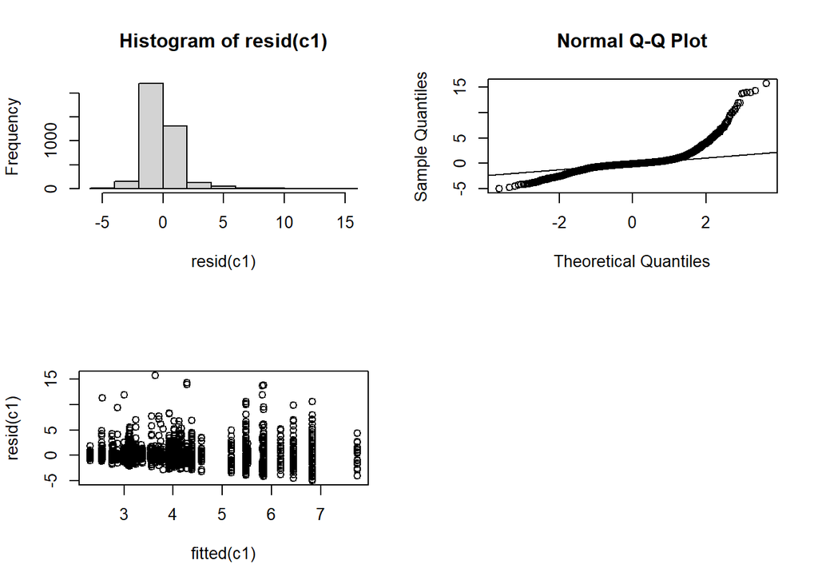

```r
par(mfrow=c(2, 2))
hist(resid(c1))
qqnorm(resid(c1));qqline(resid(c1))
plot(fitted(c1), resid(c1))
```

## Inhalation duration

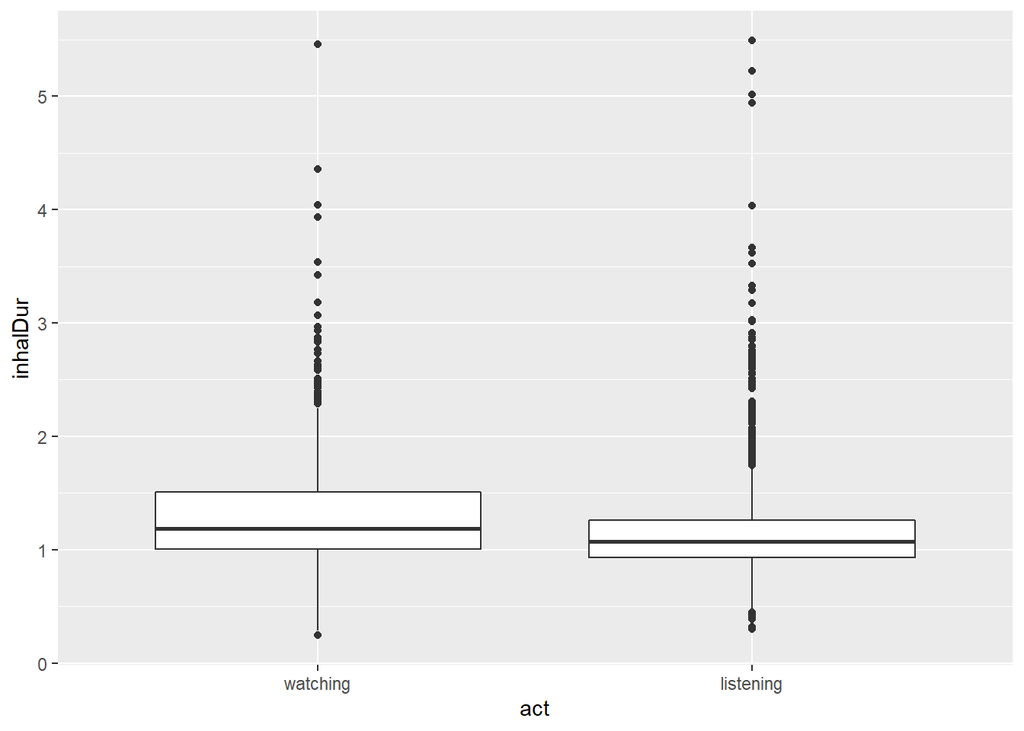

```r
ggplot(dat, aes(act, inhalDur))+
  geom_boxplot()+
  scale_x_discrete(limits = orderAct)
```

In line with the finding about breathing rate above, inhalation duration is shorter during `listening` as compared to `watching.`

Although from the graph the difference between watching and listening isn’t so clear, in the regression it seems to be.

```r
summary(d2 <- lmer(logInhalDur ~ act + (1 + act | Speaker), dat))
```

```
## Linear mixed model fit by REML ['lmerMod']
## Formula: logInhalDur ~ act + (1 + act | Speaker)
##    Data: dat
##
## REML criterion at convergence: 559.6
##
## Scaled residuals:
##     Min      1Q  Median      3Q     Max
## -6.4630 -0.4458 -0.0325  0.4150  6.7843
##
## Random effects:
##  Groups   Name         Variance Std.Dev. Corr
##  Speaker  (Intercept)  0.04132  0.2033
##           actlistening 0.01424  0.1193   -0.79
##  Residual              0.06537  0.2557
## Number of obs: 3893, groups:  Speaker, 21
##
## Fixed effects:
##              Estimate Std. Error t value
## (Intercept)   0.26046    0.04531   5.749
## actlistening -0.14218    0.02803  -5.072
##
## Correlation of Fixed Effects:
##             (Intr)
## actlistenng -0.788
```

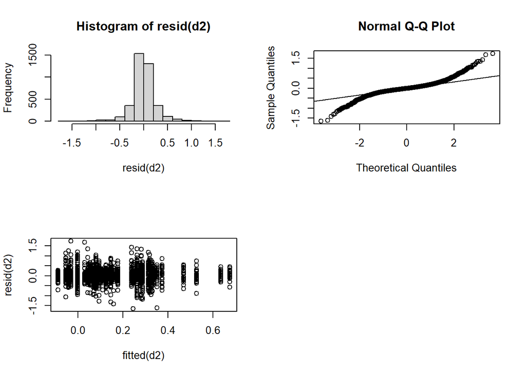

```r
par(mfrow=c(2, 2))
hist(resid(d2))
qqnorm(resid(d2));qqline(resid(d2))
plot(fitted(d2), resid(d2))
```

## Inhalation amplitude

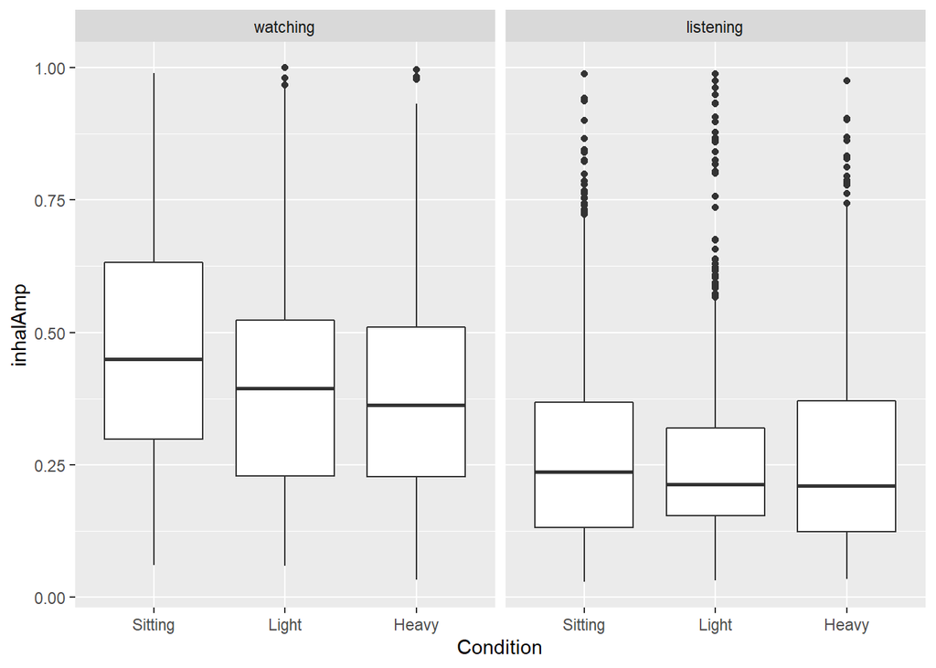

```r
ggplot(dat, aes(Condition, inhalAmp))+
  geom_boxplot()+
  scale_x_discrete(limits = orderCond)+
  facet_wrap(~act)
```

- In line with the other findings above, inhalation amplitude is lower during `listening` than `watching`.
- Condition differences: none (when we include the random slopes for condition)

```r
dat$act <- relevel(dat$act, ref = "watching")
dat$Condition <- relevel(dat$Condition, ref="Light")
summary(a3 <- lmer(inhalAmp ~ act + (1 + act | Speaker), dat))
```

```
## Linear mixed model fit by REML ['lmerMod']
## Formula: inhalAmp ~ act + (1 + act | Speaker)
##    Data: dat
##
## REML criterion at convergence: -3275.4
##
## Scaled residuals:
##     Min      1Q  Median      3Q     Max
## -2.9177 -0.6104 -0.1560  0.4102  5.0695
##
## Random effects:
##  Groups   Name         Variance Std.Dev. Corr
##  Speaker  (Intercept)  0.01240  0.1114
##           actlistening 0.01193  0.1092   -0.76
##  Residual              0.02432  0.1560
## Number of obs: 3893, groups:  Speaker, 21
##
## Fixed effects:
##              Estimate Std. Error t value
## (Intercept)   0.42817    0.02495  17.163
## actlistening -0.16345    0.02467  -6.626
##
## Correlation of Fixed Effects:
##             (Intr)
## actlistenng -0.769
```

```r
summary(a4 <- lmer(inhalAmp ~ Condition + (1 + Condition| Speaker), dat %>% filter(act=="watching")))
```

```
## Linear mixed model fit by REML ['lmerMod']
## Formula: inhalAmp ~ Condition + (1 + Condition | Speaker)
##    Data: dat %>% filter(act == "watching")
##
## REML criterion at convergence: -440
##
## Scaled residuals:
##     Min      1Q  Median      3Q     Max
## -2.9346 -0.5829 -0.1879  0.3728  4.5091
##
## Random effects:
##  Groups   Name             Variance Std.Dev. Corr
##  Speaker  (Intercept)      0.01854  0.1361
##           ConditionSitting 0.02446  0.1564   -0.47
##           ConditionHeavy   0.01378  0.1174   -0.47  0.40
##  Residual                  0.02897  0.1702
## Number of obs: 827, groups:  Speaker, 21
##
## Fixed effects:
##                  Estimate Std. Error t value
## (Intercept)       0.41368    0.03176  13.026
## ConditionSitting  0.07083    0.03755   1.886
## ConditionHeavy   -0.02764    0.02983  -0.926
##
## Correlation of Fixed Effects:
##             (Intr) CndtnS
## CondtnSttng -0.507
## ConditinHvy -0.509  0.424
```

```r
summary(a5 <- lmer(inhalAmp ~ Condition + (1 +Condition | Speaker), dat %>% filter(act=="listening")))
```

```
## Linear mixed model fit by REML ['lmerMod']
## Formula: inhalAmp ~ Condition + (1 + Condition | Speaker)
##    Data: dat %>% filter(act == "listening")
##
## REML criterion at convergence: -3793.4
##
## Scaled residuals:
##     Min      1Q  Median      3Q     Max
## -2.8169 -0.4569 -0.1760  0.1846  6.1354
##
## Random effects:
##  Groups   Name             Variance Std.Dev. Corr
##  Speaker  (Intercept)      0.006504 0.08065
##           ConditionSitting 0.016963 0.13024  -0.45
##           ConditionHeavy   0.013936 0.11805  -0.43  0.54
##  Residual                  0.015785 0.12564
## Number of obs: 3066, groups:  Speaker, 21
##
## Fixed effects:
##                  Estimate Std. Error t value
## (Intercept)       0.25464    0.01804  14.111
## ConditionSitting  0.01957    0.02896   0.676
## ConditionHeavy    0.01172    0.02647   0.443
##
## Correlation of Fixed Effects:
##             (Intr) CndtnS
## CondtnSttng -0.457
## ConditinHvy -0.437  0.536
```

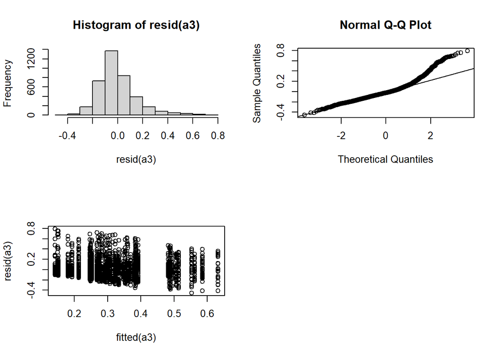

```r
par(mfrow=c(2, 2))
hist(resid(a3))
qqnorm(resid(a3));qqline(resid(a3))
plot(fitted(a3), resid(a3))
```

# Breathing data during SYNCHRONOUS READ speech

## Participants

### Breathing rate

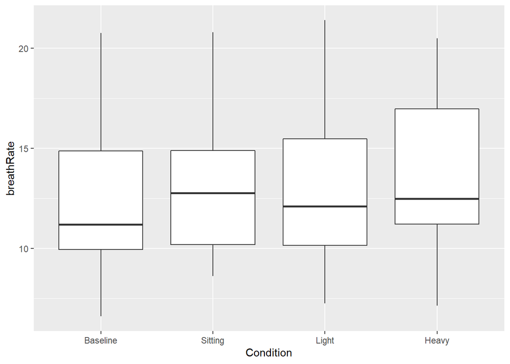

```r
ggplot(dat, aes(Condition, breathRate))+
  geom_boxplot()+
  scale_x_discrete(limits = orderCondBase)
```

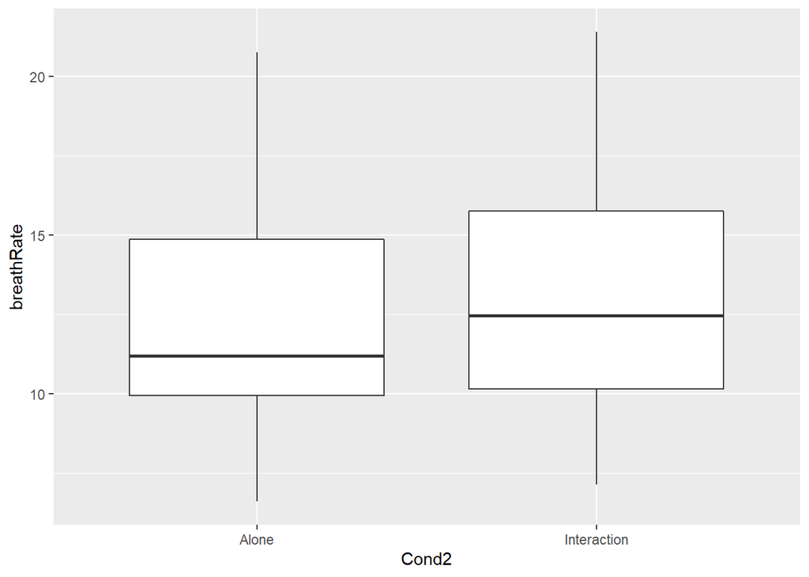

```r
ggplot(dat, aes(Cond2, breathRate))+
  geom_boxplot()
```

- Breathing rate doesn’t change across conditions (also not in baseline vs interaction).

(We had a different result before – probably because we hadn’t included random slopes for condition per participant.)

```r
summary(b1 <- lmer(breathRate ~ Cond2 + (1 + Cond2 | Speaker), dat))
```

```
## Linear mixed model fit by REML ['lmerMod']
## Formula: breathRate ~ Cond2 + (1 + Cond2 | Speaker)
##    Data: dat
##
## REML criterion at convergence: 587.2
##
## Scaled residuals:
##      Min       1Q   Median       3Q      Max
## -2.54091 -0.51523 -0.00749  0.47933  2.33383
##
## Random effects:
##  Groups   Name             Variance Std.Dev. Corr
##  Speaker  (Intercept)      13.079   3.616
##           Cond2Interaction  5.338   2.310    -0.29
##  Residual                   2.232   1.494
## Number of obs: 132, groups:  Speaker, 22
##
## Fixed effects:
##                  Estimate Std. Error t value
## (Intercept)       12.4762     0.7926  15.740
## Cond2Interaction   0.7977     0.5570   1.432
##
## Correlation of Fixed Effects:
##             (Intr)
## Cnd2Intrctn -0.323
```

```r
summary(b1 <- lmer(breathRate ~ Condition + (1| Speaker), dat))
```

```
## Linear mixed model fit by REML ['lmerMod']
## Formula: breathRate ~ Condition + (1 | Speaker)
##    Data: dat
##
## REML criterion at convergence: 610.9
##
## Scaled residuals:
##      Min       1Q   Median       3Q      Max
## -2.25281 -0.58516 -0.03704  0.54285  2.75567
##
## Random effects:
##  Groups   Name        Variance Std.Dev.
##  Speaker  (Intercept) 11.749   3.428
##  Residual              3.832   1.958
## Number of obs: 132, groups:  Speaker, 22
##
## Fixed effects:
##                   Estimate Std. Error t value
## (Intercept)       13.16674    0.84156  15.646
## ConditionBaseline -0.69053    0.48194  -1.433
## ConditionLight     0.01518    0.59025   0.026
## ConditionHeavy     0.30635    0.59025   0.519
##
## Correlation of Fixed Effects:
##             (Intr) CndtnB CndtnL
## ConditnBsln -0.430
## ConditnLght -0.351  0.612
## ConditinHvy -0.351  0.612  0.500
```

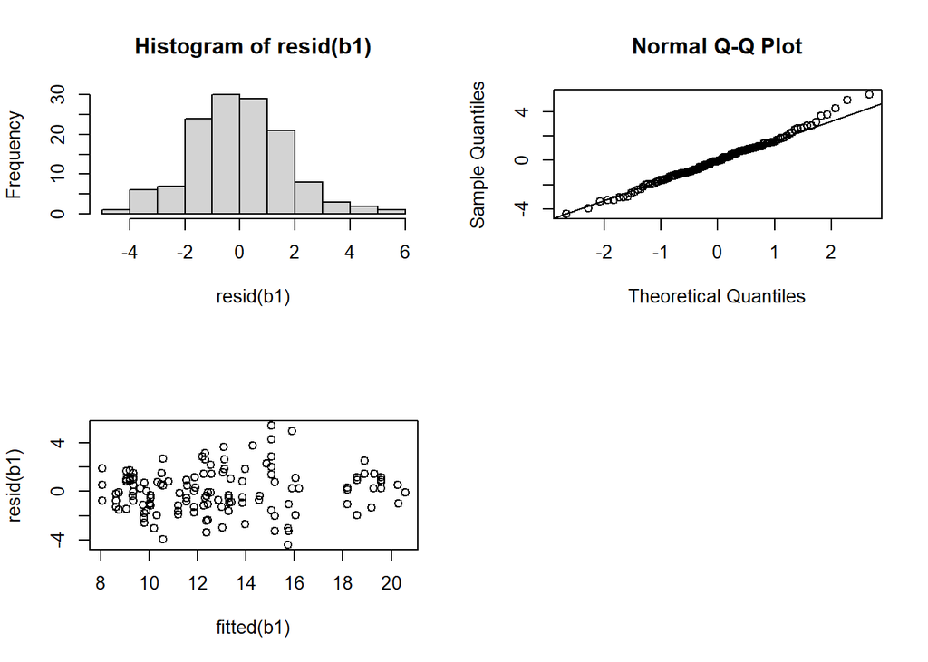

```r
par(mfrow=c(2, 2))
hist(resid(b1))
qqnorm(resid(b1));qqline(resid(b1))
plot(fitted(b1), resid(b1))
```

### Breath cycle duration

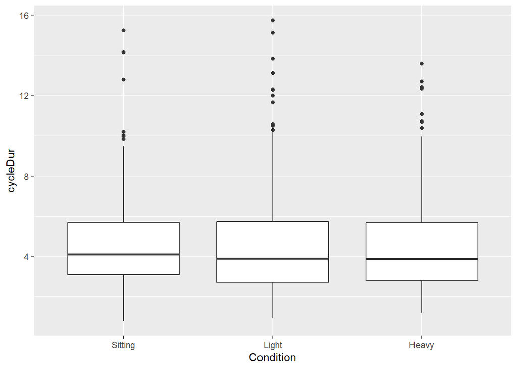

```r
ggplot(dat, aes(Condition, cycleDur))+
  geom_boxplot()+
  scale_x_discrete(limits = orderCond)
```

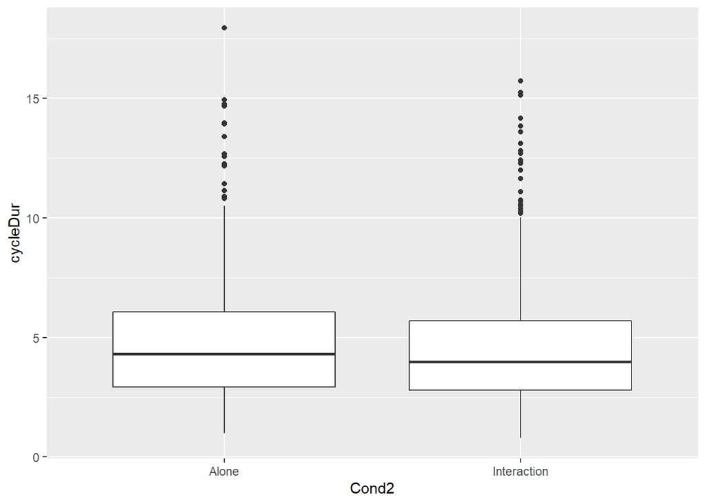

```r
ggplot(dat, aes(Cond2, cycleDur))+
  geom_boxplot()
```

There is **no** effect of condition on breath cycles.

```r
summary(b1 <- lmer(cycleDur ~ Condition + (1 | Speaker), dat))
```

```
## Linear mixed model fit by REML ['lmerMod']
## Formula: cycleDur ~ Condition + (1 | Speaker)
##    Data: dat
##
## REML criterion at convergence: 7536.9
##
## Scaled residuals:
##     Min      1Q  Median      3Q     Max
## -2.8149 -0.6393 -0.1114  0.5083  5.4459
##
## Random effects:
##  Groups   Name        Variance Std.Dev.
##  Speaker  (Intercept) 1.574    1.255
##  Residual             4.227    2.056
## Number of obs: 1743, groups:  Speaker, 22
##
## Fixed effects:
##                   Estimate Std. Error t value
## (Intercept)        4.84184    0.29444  16.444
## ConditionBaseline  0.25862    0.14397   1.796
## ConditionLight     0.06970    0.16753   0.416
## ConditionHeavy    -0.07893    0.16306  -0.484
##
## Correlation of Fixed Effects:
##             (Intr) CndtnB CndtnL
## ConditnBsln -0.355
## ConditnLght -0.304  0.625
## ConditinHvy -0.313  0.641  0.551
```

```r
summary(b1a <- lmer(cycleDur ~ Cond2 + (1 + Cond2 | Speaker), dat))
```

```
## Linear mixed model fit by REML ['lmerMod']
## Formula: cycleDur ~ Cond2 + (1 + Cond2 | Speaker)
##    Data: dat
##
## REML criterion at convergence: 7487.6
##
## Scaled residuals:
##     Min      1Q  Median      3Q     Max
## -2.7003 -0.6261 -0.1164  0.5212  5.3175
##
## Random effects:
##  Groups   Name             Variance Std.Dev. Corr
##  Speaker  (Intercept)      1.7185   1.3109
##           Cond2Interaction 0.9057   0.9517   -0.29
##  Residual                  4.0311   2.0078
## Number of obs: 1743, groups:  Speaker, 22
##
## Fixed effects:
##                  Estimate Std. Error t value
## (Intercept)        5.1604     0.2897  17.812
## Cond2Interaction  -0.2913     0.2267  -1.285
##
## Correlation of Fixed Effects:
##             (Intr)
## Cnd2Intrctn -0.343
```

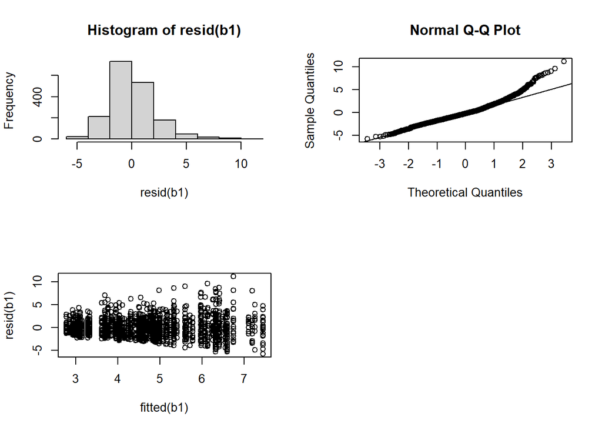

```r
par(mfrow=c(2, 2))
hist(resid(b1))
qqnorm(resid(b1));qqline(resid(b1))
plot(fitted(b1), resid(b1))

par(mfrow=c(2, 2))
```

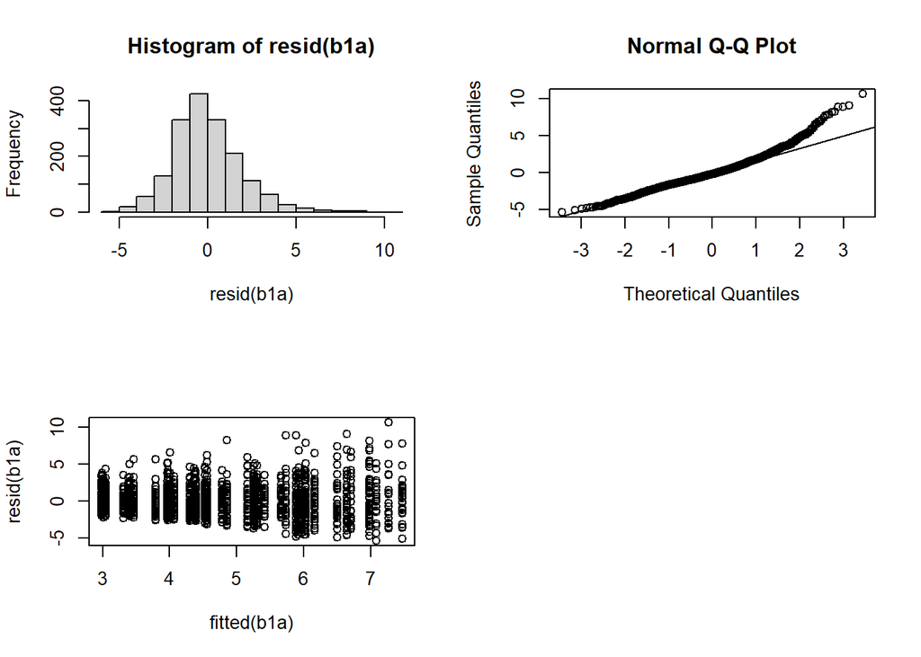

```r
hist(resid(b1a))
qqnorm(resid(b1a));qqline(resid(b1a))
plot(fitted(b1a), resid(b1a))
```

### Inhalation duration

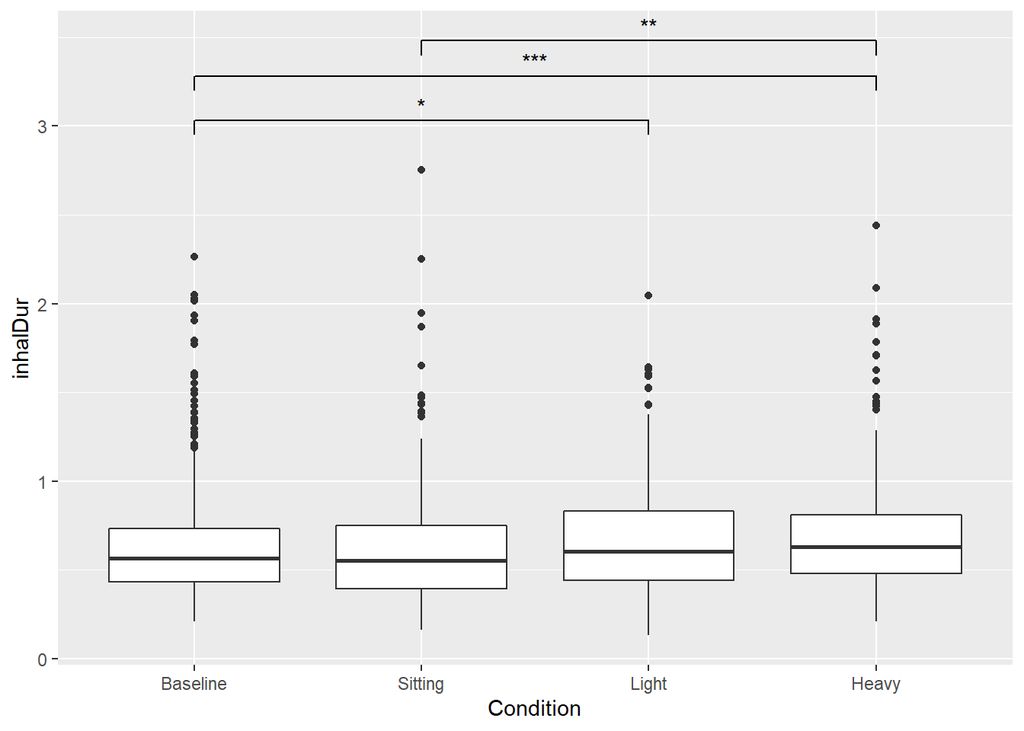

```r
ggplot(dat %>% filter(inhalDur < 3), aes(Condition, inhalDur))+
  geom_boxplot()+
  scale_x_discrete(limits = orderCondBase)+
  geom_signif(comparisons=list(c("Baseline", "Light"), c("Baseline", "Heavy"), c("Sitting", "Heavy")),
              annotations=c("*", "***", "**"),
              y=c(2.9, 3.15, 3.35))
```

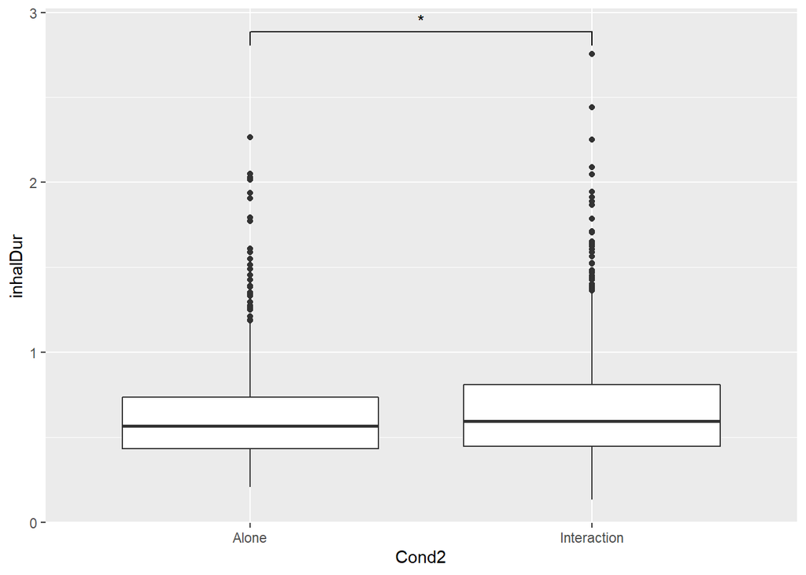

```r
ggplot(dat %>% filter(inhalDur < 3), aes(Cond2, inhalDur))+
  geom_boxplot()+
    geom_signif(comparisons=list(c("Alone", "Interaction")),
                annotations=c("*"))
```

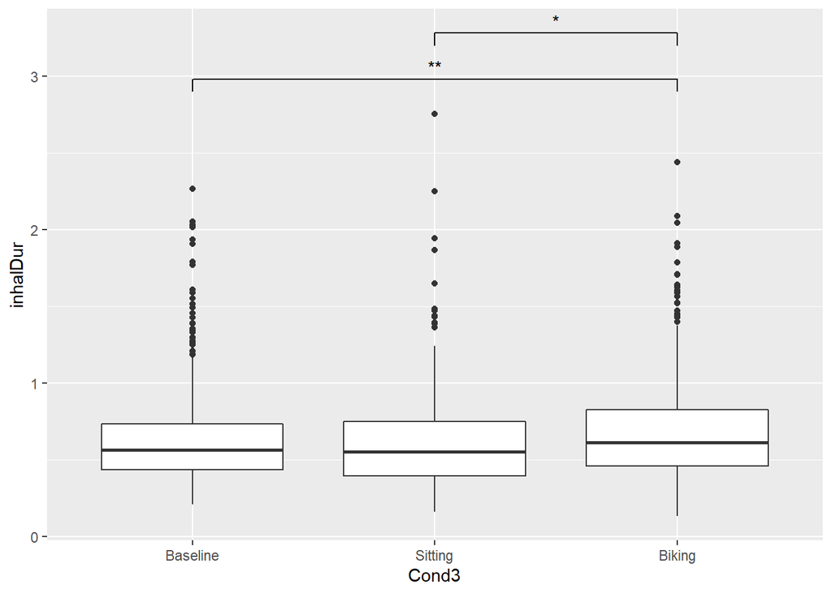

```r
ggplot(dat %>% filter(inhalDur < 3), aes(Cond3, inhalDur))+
  geom_boxplot()+
  scale_x_discrete(limits = c("Baseline", "Sitting", "Biking"))+
      geom_signif(comparisons=list(c("Baseline", "Biking"), c("Sitting", "Biking")),
                annotations=c("**", "*"),
                y=c(2.85, 3.15))
```

- **Considering each condition separately:** Sitting = baseline, and then it seems that there are small increases for light and heavy. See significances in graph above.
- **Considering baseline vs interaction:** longer inhalation duration during interaction, but very small effect
- **Considering baseline vs sitting vs biking:** Sitting = baseline, and inhalations longer during biking

Inhalations also get shorter the further into the recording they are, like for cycle durations above. If we report the model about inhalation duration, I suggest we only leave the `condition` predictor, unless we want to talk about this change in durations across the task.

```r
dat$Condition <- relevel(dat$Condition, ref="Sitting")
dat$Cond3 <- relevel(dat$Cond3, ref="Baseline")
summary(d5 <- lmer(inhalDur ~ Condition + (1 | Speaker), dat))
```

```
## Linear mixed model fit by REML ['lmerMod']
## Formula: inhalDur ~ Condition + (1 | Speaker)
##    Data: dat
##
## REML criterion at convergence: 920
##
## Scaled residuals:
##     Min      1Q  Median      3Q     Max
## -1.8653 -0.6151 -0.1941  0.3653 13.6524
##
## Random effects:
##  Groups   Name        Variance Std.Dev.
##  Speaker  (Intercept) 0.01303  0.1142
##  Residual             0.09517  0.3085
## Number of obs: 1743, groups:  Speaker, 22
##
## Fixed effects:
##                     Estimate Std. Error t value
## (Intercept)        0.6428572  0.0305500  21.043
## ConditionBaseline -0.0001616  0.0215959  -0.007
## ConditionLight     0.0443321  0.0251335   1.764
## ConditionHeavy     0.0798565  0.0244644   3.264
##
## Correlation of Fixed Effects:
##             (Intr) CndtnB CndtnL
## ConditnBsln -0.513
## ConditnLght -0.440  0.625
## ConditinHvy -0.452  0.641  0.551
```

```r
summary(d5a <- lmer(inhalDur ~ Cond2 + (1 + Cond2 | Speaker), dat))
```

```
## Linear mixed model fit by REML ['lmerMod']
## Formula: inhalDur ~ Cond2 + (1 + Cond2 | Speaker)
##    Data: dat
##
## REML criterion at convergence: 897.6
##
## Scaled residuals:
##     Min      1Q  Median      3Q     Max
## -1.8259 -0.5968 -0.1907  0.3710 13.8424
##
## Random effects:
##  Groups   Name             Variance Std.Dev. Corr
##  Speaker  (Intercept)      0.014480 0.12033
##           Cond2Interaction 0.009616 0.09806  -0.33
##  Residual                  0.093241 0.30535
## Number of obs: 1743, groups:  Speaker, 22
##
## Fixed effects:
##                  Estimate Std. Error t value
## (Intercept)       0.64073    0.02813  22.779
## Cond2Interaction  0.05195    0.02589   2.007
##
## Correlation of Fixed Effects:
##             (Intr)
## Cnd2Intrctn -0.426
```

```r
summary(d5b <- lmer(inhalDur ~ Cond3 + (1  | Speaker), dat))
```

```
## Linear mixed model fit by REML ['lmerMod']
## Formula: inhalDur ~ Cond3 + (1 | Speaker)
##    Data: dat
##
## REML criterion at convergence: 916.6
##
## Scaled residuals:
##     Min      1Q  Median      3Q     Max
## -1.8083 -0.6183 -0.1987  0.3512 13.7032
##
## Random effects:
##  Groups   Name        Variance Std.Dev.
##  Speaker  (Intercept) 0.01307  0.1143
##  Residual             0.09524  0.3086
## Number of obs: 1743, groups:  Speaker, 22
##
## Fixed effects:
##               Estimate Std. Error t value
## (Intercept)  0.6427478  0.0269193  23.877
## Cond3Biking  0.0632854  0.0162815   3.887
## Cond3Sitting 0.0001245  0.0216035   0.006
##
## Correlation of Fixed Effects:
##             (Intr) Cnd3Bk
## Cond3Biking -0.289
## Cond3Sittng -0.220  0.363
```

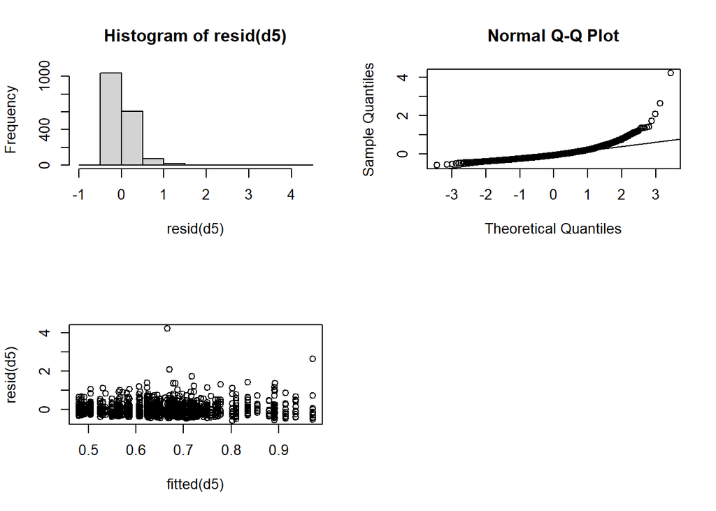

```r
par(mfrow=c(2, 2))
hist(resid(d5))
qqnorm(resid(d5));qqline(resid(d5))
plot(fitted(d5), resid(d5))
```

### Inhalation amplitude

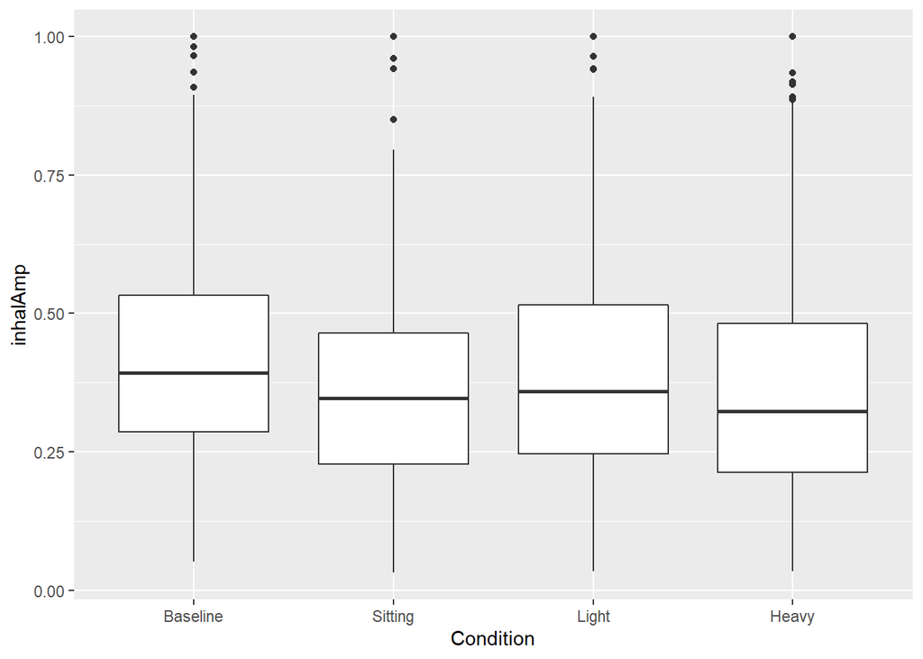

```r
ggplot(dat, aes(Condition, inhalAmp))+
  geom_boxplot()+
  scale_x_discrete(limits = orderCondBase)
```

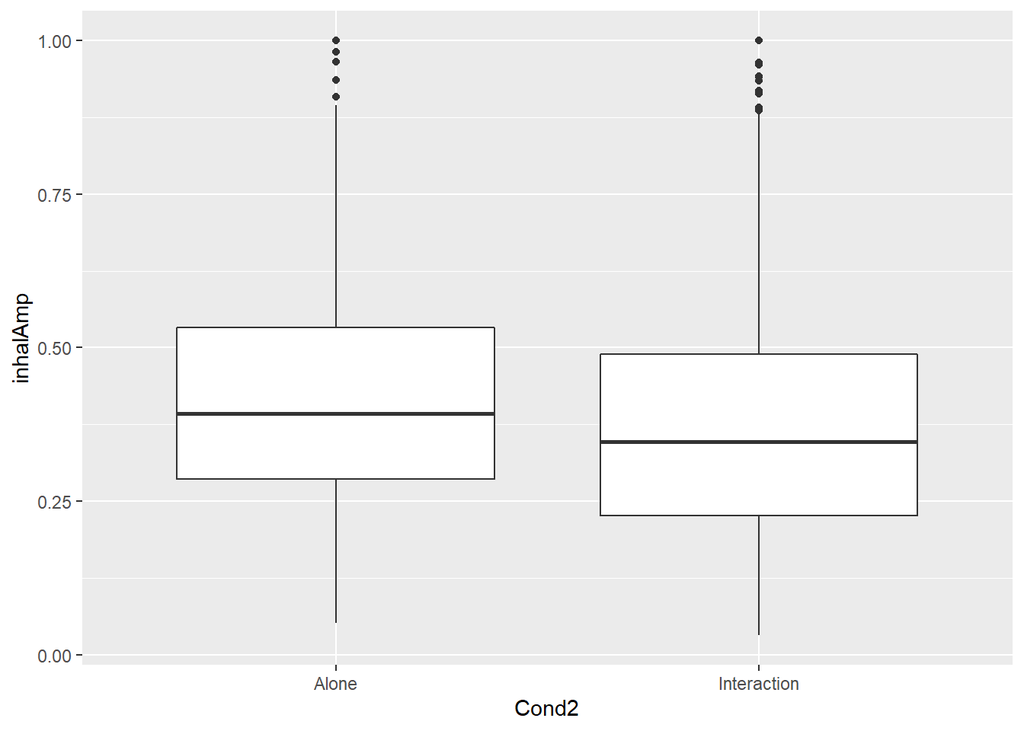

```r
ggplot(dat, aes(Cond2, inhalAmp))+
  geom_boxplot()
```

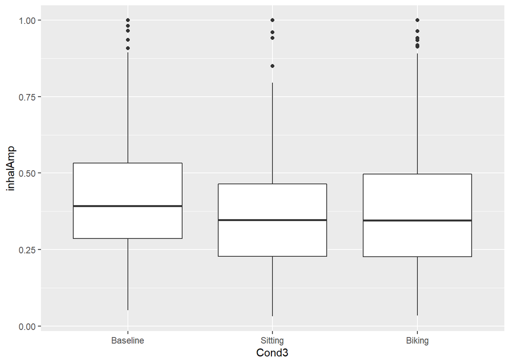

```r
ggplot(dat, aes(Cond3, inhalAmp))+
  geom_boxplot()+
  scale_x_discrete(limits = c("Baseline", "Sitting", "Biking"))
```

```r
dat$Condition <- relevel(dat$Condition, ref="Baseline")
dat$Cond3 <- relevel(dat$Cond3, ref="Sitting")

summary(a1 <- lmer(inhalAmp ~ Condition + (1 + Condition | Speaker), dat))
```

```
## Linear mixed model fit by REML ['lmerMod']
## Formula: inhalAmp ~ Condition + (1 + Condition | Speaker)
##    Data: dat
##
## REML criterion at convergence: -1022.3
##
## Scaled residuals:
##     Min      1Q  Median      3Q     Max
## -2.4783 -0.7061 -0.0952  0.5884  3.8529
##
## Random effects:
##  Groups   Name             Variance Std.Dev. Corr
##  Speaker  (Intercept)      0.004035 0.06352
##           ConditionSitting 0.003190 0.05648  -0.52
##           ConditionLight   0.010271 0.10135  -0.40  0.98
##           ConditionHeavy   0.006453 0.08033  -0.06  0.64  0.56
##  Residual                  0.030277 0.17400
## Number of obs: 1743, groups:  Speaker, 22
##
## Fixed effects:
##                  Estimate Std. Error t value
## (Intercept)       0.43344    0.01505  28.798
## ConditionSitting -0.07332    0.01720  -4.262
## ConditionLight   -0.02561    0.02471  -1.036
## ConditionHeavy   -0.05749    0.02058  -2.793
##
## Correlation of Fixed Effects:
##             (Intr) CndtnS CndtnL
## CondtnSttng -0.490
## ConditnLght -0.429  0.705
## ConditinHvy -0.186  0.497  0.495
```

```r
summary(a2 <- lmer(inhalAmp ~ Cond2 + (1 + Cond2 | Speaker), dat))
```

```
## Linear mixed model fit by REML ['lmerMod']
## Formula: inhalAmp ~ Cond2 + (1 + Cond2 | Speaker)
##    Data: dat
##
## REML criterion at convergence: -1004.2
##
## Scaled residuals:
##     Min      1Q  Median      3Q     Max
## -2.4629 -0.7079 -0.1054  0.6058  3.8361
##
## Random effects:
##  Groups   Name             Variance Std.Dev. Corr
##  Speaker  (Intercept)      0.004046 0.06361
##           Cond2Interaction 0.005208 0.07216  -0.35
##  Residual                  0.031208 0.17666
## Number of obs: 1743, groups:  Speaker, 22
##
## Fixed effects:
##                  Estimate Std. Error t value
## (Intercept)       0.43319    0.01512  28.658
## Cond2Interaction -0.05282    0.01775  -2.975
##
## Correlation of Fixed Effects:
##             (Intr)
## Cnd2Intrctn -0.439
```

```r
summary(a3 <- lmer(inhalAmp ~ Cond3 + (1  | Speaker), dat))
```

```
## Linear mixed model fit by REML ['lmerMod']
## Formula: inhalAmp ~ Cond3 + (1 | Speaker)
##    Data: dat
##
## REML criterion at convergence: -965.3
##
## Scaled residuals:
##     Min      1Q  Median      3Q     Max
## -2.5332 -0.7221 -0.1000  0.5948  3.8656
##
## Random effects:
##  Groups   Name        Variance Std.Dev.
##  Speaker  (Intercept) 0.004002 0.06326
##  Residual             0.032329 0.17980
## Number of obs: 1743, groups:  Speaker, 22
##
## Fixed effects:
##               Estimate Std. Error t value
## (Intercept)    0.35914    0.01725  20.814
## Cond3Baseline  0.07697    0.01259   6.116
## Cond3Biking    0.02318    0.01272   1.823
##
## Correlation of Fixed Effects:
##             (Intr) Cnd3Bs
## Cond3Baseln -0.530
## Cond3Biking -0.523  0.719
```

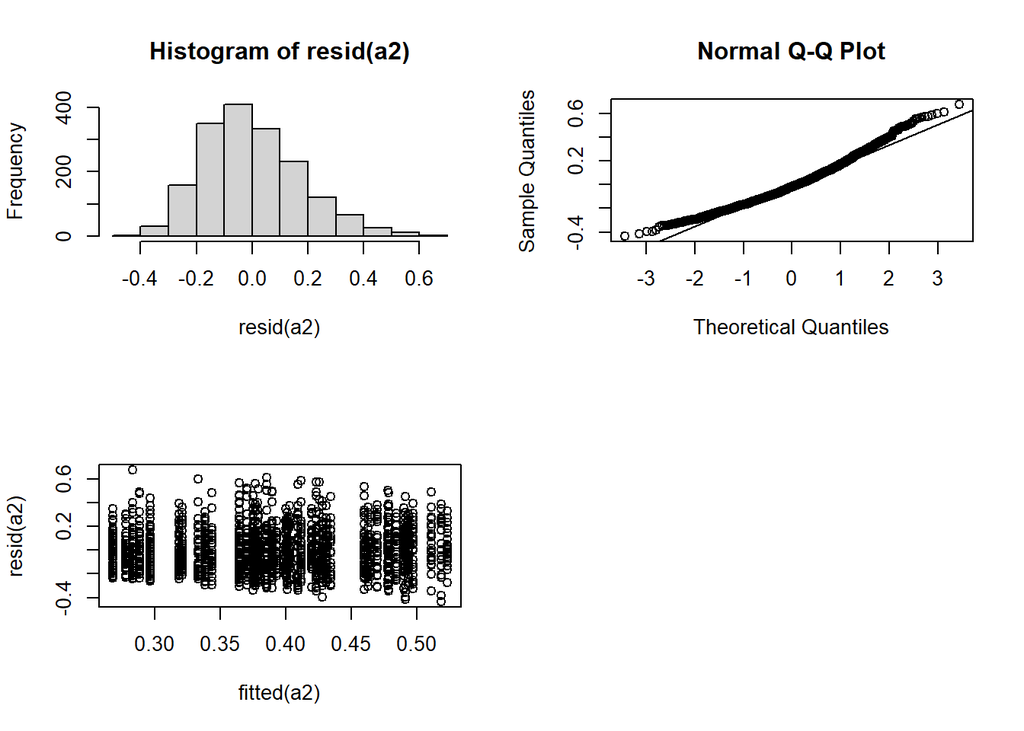

```r
par(mfrow=c(2, 2))
hist(resid(a2))
qqnorm(resid(a2));qqline(resid(a2))
plot(fitted(a2), resid(a2))
```

## Confederate

### Breathing rate

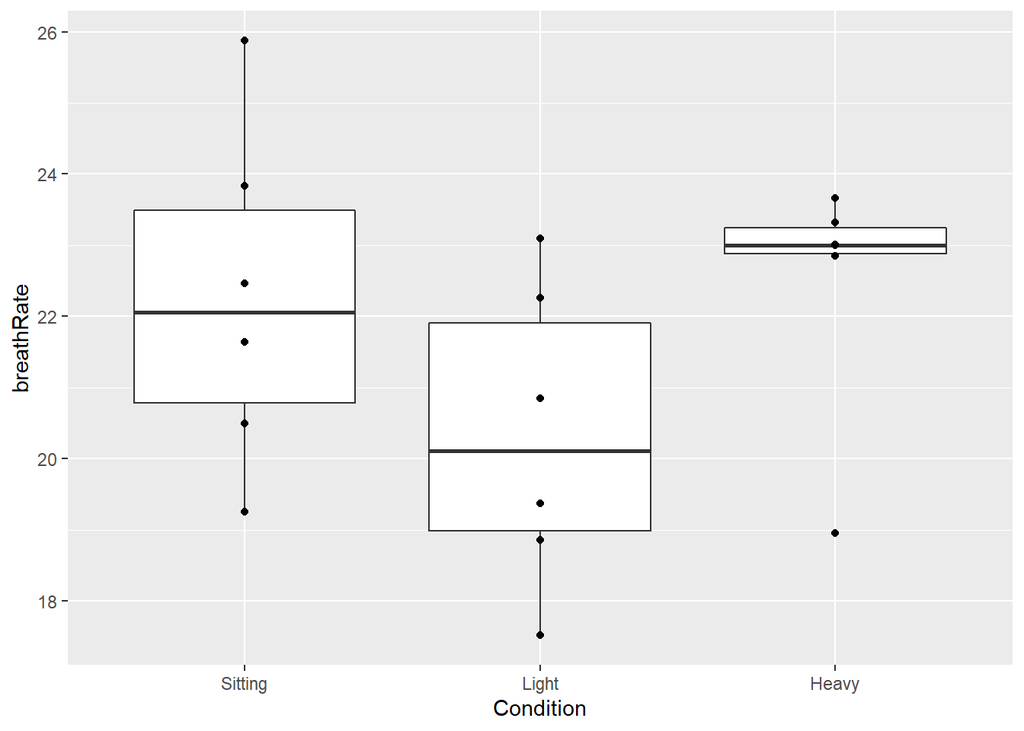

```r
ggplot(df, aes(Condition, breathRate))+
  geom_boxplot()+
  geom_point()
```

During read speech, the confederate’s breathing rate had this non-pattern. Maybe the linguistic demands of read speech overrode the oxygen demands? (Here, assuming that the confederate did already have enough oxygen with this breathing rate.)

```r
df$Condition <- relevel(df$Condition, ref="Sitting")
summary(b1 <- lm(breathRate ~ Condition, df))
```

```
##
## Call:
## lm(formula = breathRate ~ Condition, data = df)
##
## Residuals:
##     Min      1Q  Median      3Q     Max
## -3.5070 -1.3404  0.4533  1.1114  3.6157
##
## Coefficients:
##                Estimate Std. Error t value Pr(>|t|)
## (Intercept)     22.2598     0.8562  26.000 6.85e-14 ***
## ConditionLight  -1.9336     1.2108  -1.597    0.131
## ConditionHeavy   0.2074     1.2108   0.171    0.866
## ---
## Signif. codes:  0 '***' 0.001 '**' 0.01 '*' 0.05 '.' 0.1 ' ' 1
##
## Residual standard error: 2.097 on 15 degrees of freedom
## Multiple R-squared:  0.2023, Adjusted R-squared:  0.09595
## F-statistic: 1.902 on 2 and 15 DF,  p-value: 0.1836
```

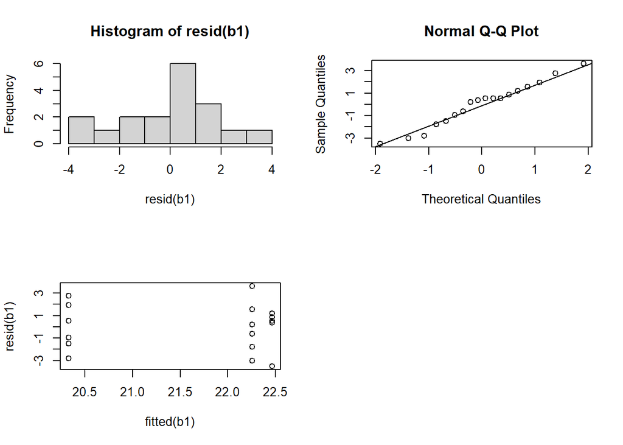

```r
par(mfrow=c(2, 2))
hist(resid(b1))
qqnorm(resid(b1));qqline(resid(b1))
plot(fitted(b1), resid(b1))
```

### Breath cycle duration

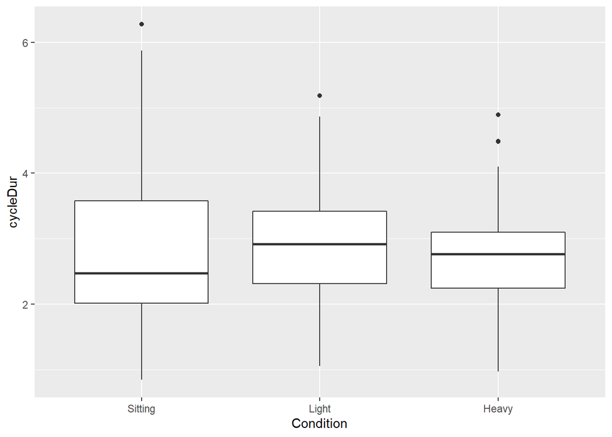

```r
ggplot(dat, aes(Condition, cycleDur))+
  geom_boxplot()+
  scale_x_discrete(limits = orderCond)
```

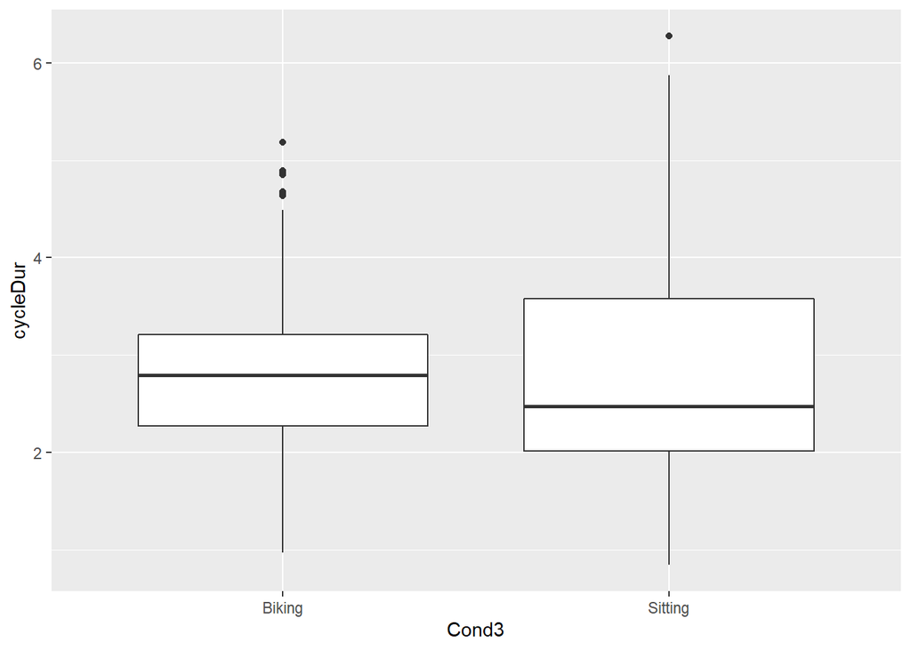

```r
ggplot(dat, aes(Cond3, cycleDur))+
  geom_boxplot()
```

```r
summary(b1 <- lm(cycleDur ~ Condition, dat))
```

```
##
## Call:
## lm(formula = cycleDur ~ Condition, data = dat)
##
## Residuals:
##     Min      1Q  Median      3Q     Max
## -1.8817 -0.5705  0.0080  0.4663  3.5632
##
## Coefficients:
##                Estimate Std. Error t value Pr(>|t|)
## (Intercept)     2.71024    0.07982  33.952   <2e-16 ***
## ConditionLight  0.23239    0.11200   2.075   0.0386 *
## ConditionHeavy -0.04277    0.10710  -0.399   0.6898
## ---
## Signif. codes:  0 '***' 0.001 '**' 0.01 '*' 0.05 '.' 0.1 ' ' 1
##
## Residual standard error: 0.8889 on 404 degrees of freedom
## Multiple R-squared:  0.0181, Adjusted R-squared:  0.01324
## F-statistic: 3.723 on 2 and 404 DF,  p-value: 0.02499
```

```r
summary(b1a <- lm(cycleDur ~ Cond3, dat))
```

```
##
## Call:
## lm(formula = cycleDur ~ Cond3, data = dat)
##
## Residuals:
##     Min      1Q  Median      3Q     Max
## -1.8631 -0.5756 -0.0181  0.4442  3.5632
##
## Coefficients:
##              Estimate Std. Error t value Pr(>|t|)
## (Intercept)   2.79192    0.05321  52.469   <2e-16 ***
## Cond3Sitting -0.08169    0.09640  -0.847    0.397
## ---
## Signif. codes:  0 '***' 0.001 '**' 0.01 '*' 0.05 '.' 0.1 ' ' 1
##
## Residual standard error: 0.8951 on 405 degrees of freedom
## Multiple R-squared:  0.00177,    Adjusted R-squared:  -0.000695
## F-statistic: 0.718 on 1 and 405 DF,  p-value: 0.3973
```

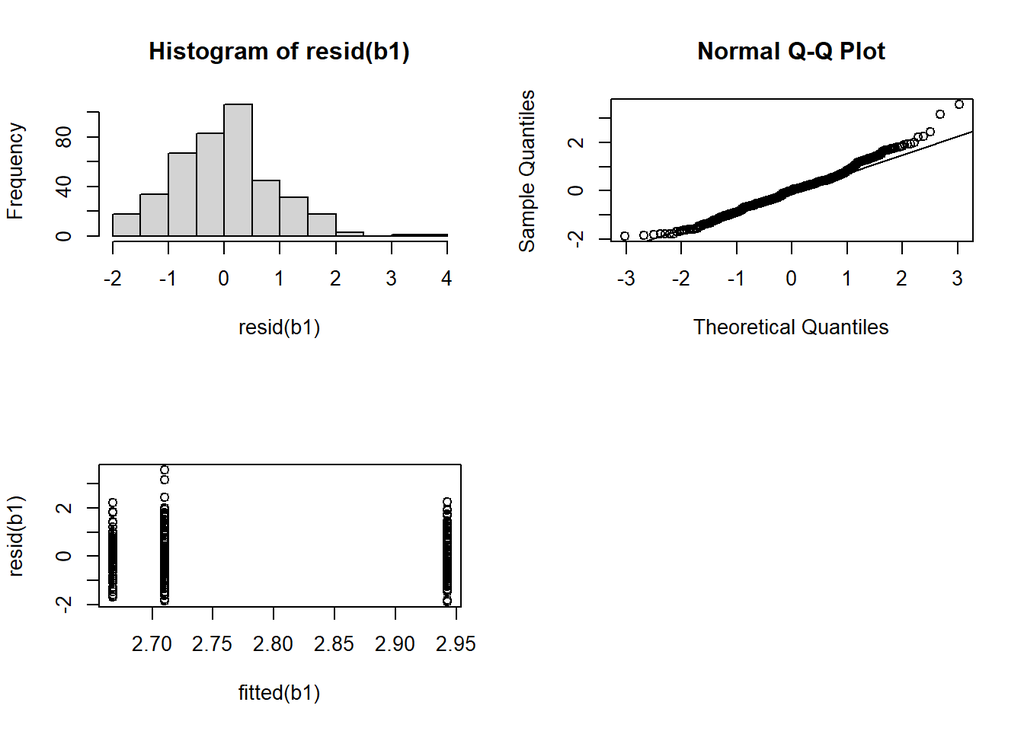

```r
par(mfrow=c(2, 2))
hist(resid(b1))
qqnorm(resid(b1));qqline(resid(b1))
plot(fitted(b1), resid(b1))

par(mfrow=c(2, 2))
```

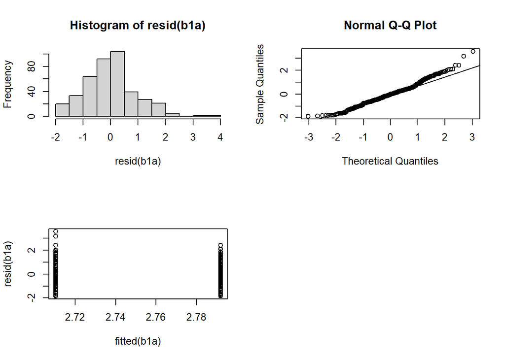

```r
hist(resid(b1a))
qqnorm(resid(b1a));qqline(resid(b1a))
plot(fitted(b1a), resid(b1a))
```